# UK Accidents Data Exploraion

## by (Mervat Khaled)

## Investigation Overview

> In this investigation, I wanted to look at what causes Serious and Not Serious accidents. The main focus was on: road type, time, age of driver, age of the vehicle, Driver IMD deprivation, speed limit...

## Dataset Overview

> This data provide details about the circumstances of personal injury road accidents in Great Britain from 2005 to 2014, the types of vehicles involved, and the consequential casualties. The statistics relate only to personal injury accidents on public roads that are reported to the police and subsequently recorded, using the STATS19 accident reporting form. Information on damage-only accidents, with no human casualties or accidents on private roads or car parks, is not included in this data.

### Did driver age has an effect in the number of accidents?

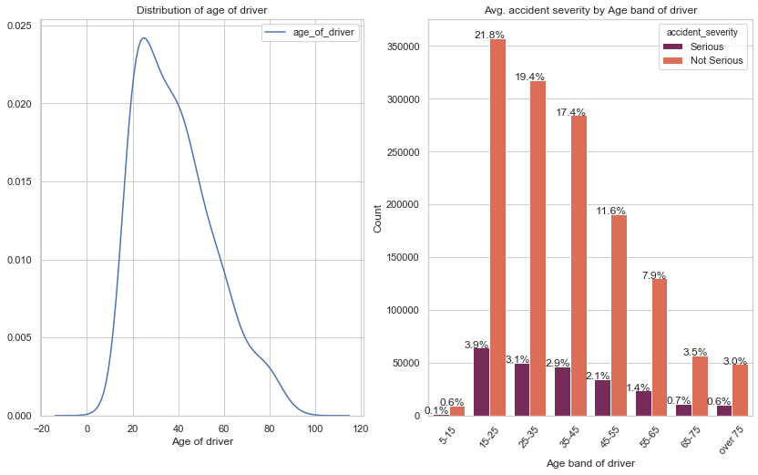

```python
sb.set(font_scale=2)
sb.set(style="whitegrid")
plt.figure(figsize=[14,8])
plt.subplot(1, 2, 1)
sb.kdeplot(uk_accidents_2.age_of_driver, bw=5)
plt.title('Distribution of age of driver')
plt.xlabel('Age of driver')

plt.subplot(1, 2, 2)
counts = uk_accidents['age_band_of_driver'].value_counts()
n_age_band=uk_accidents['age_band_of_driver'].value_counts().sum()

ax = sb.countplot(data = uk_accidents, x = 'age_band_of_driver', hue = 'accident_severity',\
             palette='rocket')
plt.xlabel('Age band of driver')
plt.ylabel('Count')
plt.title('Avg. accident severity by Age band of driver')
plt.xticks(rotation=50)
for p in ax.patches:
    percentage = '{:.1f}%'.format(100 * p.get_height()/n_age_band)
    x = p.get_x() + p.get_width()
    y = p.get_height()
    ax.annotate(percentage, (x, y),ha='right')
plt.savefig('age_of_driver.png')
plt.show()
```

> The left figure depicts The distribution of drivers' ages involved in accidents, it can be noted that the most frequent ages clumped up between 15-35. And bar chart highlights the trend of serious accidents,We clearly see people from 15 to 45 have a higher precentage of serious accidents than other bands.

### When did accidents usually happen?

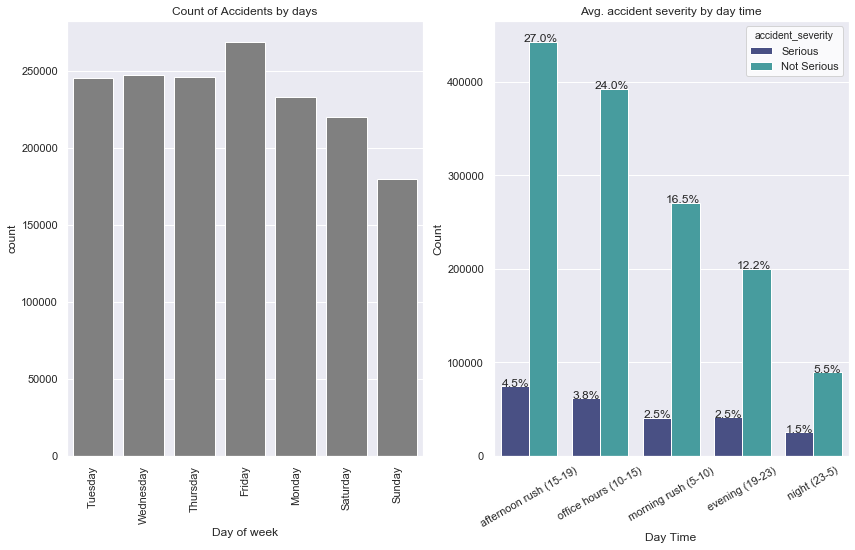

```python
sb.set(font_scale=1)
plt.figure(figsize=[14,8])
plt.subplot(1, 2, 1)
sb.countplot(x=uk_accidents_2.day_of_week,color='grey')
plt.title("Count of Accidents by days")
plt.xlabel('Day of week')
plt.xticks(rotation=90);
plt.subplot(1, 2, 2)
sb.set(style="whitegrid")
counts = uk_accidents['day_time'].value_counts()
n_day_time=uk_accidents['day_time'].value_counts().sum()

ax = sb.countplot(data = uk_accidents, x = 'day_time', hue = 'accident_severity',\
             palette='mako',order=uk_accidents.day_time.value_counts().index)
plt.xlabel('Day Time')
plt.ylabel('Count')
plt.title('Avg. accident severity by day time')
plt.xticks(rotation=30)
for p in ax.patches:
    percentage = '{:.1f}%'.format(100 * p.get_height()/n_day_time)
    x = p.get_x() + p.get_width()
    y = p.get_height()
    ax.annotate(percentage, (x, y),ha='right')
plt.savefig('accidents_by_days.png')
plt.show()
```

### The total annual accidents

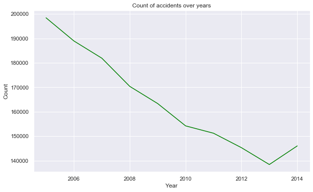

```python
sb.set()
plt.figure(figsize=[10,6])
sb.lineplot(x=uk_accidents_2.year.value_counts().index,y=uk_accidents.year.value_counts().values ,color='green')
plt.xlabel('Year')
plt.ylabel('Count')
plt.title('Count of accidents over years');
```

> The line graph shows that the number of accidents from 2005 to 2012 declined, however, there is a slight spike in the number from 2013 to 2014.

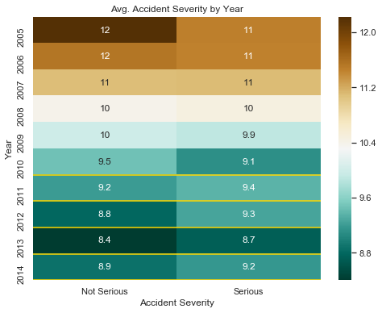

```python
plot_clusterd_heatmap2(uk_accidents,'year','accident_severity',[6,7,8,9,10]);
```

> Also from 2011 to 2014, There has been a slight spike in the percentage of serious accidents than Not serious accidents.

### Was the accident severity dependent on social class?

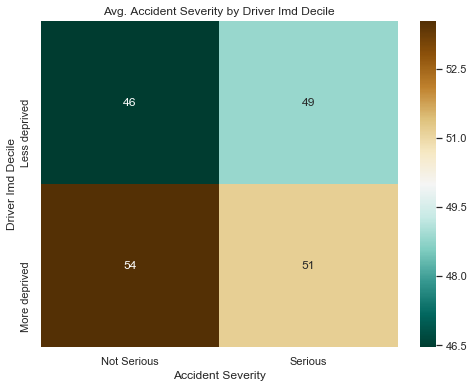

```python
plot_clusterd_heatmap2(uk_accidents_not_missing,'driver_imd_decile','accident_severity');
```

> Before we describe what happens in the graph, we should define what IMD Deprivation means.
> - An Index of Multiple Deprivation [IMD](https://en.wikipedia.org/wiki/Multiple_deprivation_index) is used to identify how deprived an area is. It uses a range of economic, social, and housing data to create a single deprivation score for each small area of the country.
> - There seven domains of deprivation are considered and weighted as follows: 1- Income Deprivation 22.5 % 2- Employment Deprivation 22.5% 3- Health Deprivation and Disability 13.5% 4- Education, Skills and Training Deprivation 13.5% 5- Barriers to Housing and Services 9.3% 6- Crime 9.3% 7- Living Environment Deprivation 9.3% Anyway, the graph shows that areas which had more deprivation "with low-quality services" had a higher percentage of a number of accidents than fewer deprivation areas, however, fewer deprivation areas had a slightly higher percentage of serious accidents than a slight accident.

### Did the age of the vehicle have an effect on accidents?

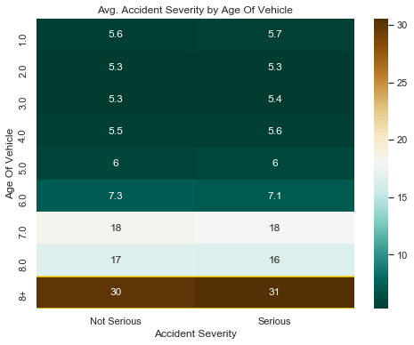

```python
plot_clusterd_heatmap2(uk_accidents,'age_of_vehicle','accident_severity',[8,9]);
```

### Did speed limit and road type have an influence on the seriousness of accidents?

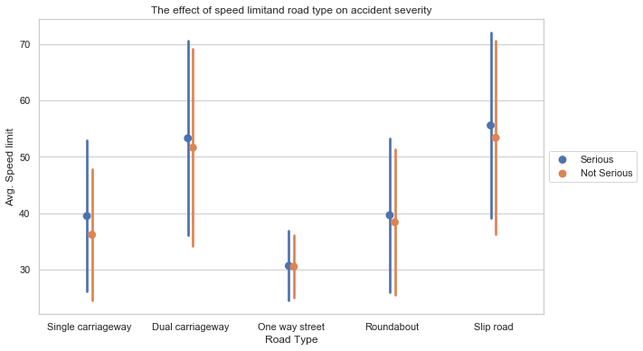

```python
plt.figure(figsize=(10,6))
sb.pointplot(data=uk_accidents.loc[~uk_accidents.road_type.isin(['Unknown'])],x='road_type',y='speed_limit',\
             hue='accident_severity',ci='sd',linestyles="",dodge=True)
plt.ylabel('Avg. Speed limit')
plt.xlabel('Road Type')
plt.title('The effect of speed limitand road type on accident severity')
plt.savefig('accidents_by_speed.png')
plt.legend(loc='center left', bbox_to_anchor=(1, 0.5));
```

```python
!jupyter nbconvert slide_deck_template.ipynb --to slides --post serve --template output_toggle.tpl
```

[output not shown]